**Medidas de Divergencia en Modelos de Predicción Binaria.**

Luis Horna PhD., Alex Pérez Ing. Mat., Diego Huaraca Ing. Mat.

Departamento de Matemáticas. Facultad de Ciencias.

Escuela Politécnica Nacional

*22 de junio de 2015.*

El presente documento tiene como propósito describir a detalle el flujograma de la figura siguiente, así como las funciones utilizadas en el cálculo automático de varias medidas de divergencia en modelos de predicción binaria mediante R.

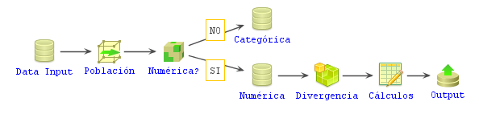

**Nodo: Data Input**

La tarea que se ejecuta en el nodo **Data Input** corresponde a la lectura de un archivo de datos desde **SPSS** (formato .sav) mediante la función `read.spss()` del paquete `foreign`o desde **Excel** (formatos .xls, .xlsx) a través de la función `read_excel()` del paquete `readxl`.

El conjunto de datos a analizar debe presentar la siguiente estructura:

- Variable dependiente,
- Variables independientes.

En nuestro caso, a manera de ejemplo consideramos el siguiente conjunto de datos:

```r
library(foreign)
# library(readxl)
data <- read.spss("data_act.sav", use.value.labels=FALSE, to.data.frame=TRUE)
# data <- read_excel("data_act.xlsx", sheet=1, na="")
#str(data)
#library(js)
#DT::datatable(round(data[1:50,],2), filter="top",options = list(
#  searching = TRUE,
#  pageLength = 5,
#  lengthMenu = c(5, 10, 15)
#))
```

El objeto `data` es un `data frame` con 15105 observaciones y 15 variables. La variable a predecir `var.dep` es una variable binaria que analiza la activación (realizar al menos un consumo) de una tarjeta de crédito (tc) en una ventana de tiempo determinada, definida como sigue:

$var.dep =\left\{\begin{array}{ll} 1, &\mbox{si se activa la tc},\\ 0, &\mbox{caso contrario.} \end{array} \right.$

**Nodo: Población**

La tarea que se ejecuta en el nodo **Población** consiste únicamente en mostrar la distribución que presenta la variable dependiente binaria; permite conocer en que relación se encuentra el número de éxitos (activa) respecto al número de fracasos (no activa).

```r
vardep <- data[,"var.dep"]
table(vardep)
```

```
## vardep
##     0     1
##  5031 10074
```

En nuestro caso tenemos la proporción 2.002, es decir, por cada sujeto no activa tenemos aproximadamente 2 activa.

**Nodo: Numérica**

En el nodo **Numérica**, se crea una variable `tipo.var`, la misma que permite identificar las variables numéricas y las categóricas.

```r
# Variable numérica o categórica
tipo.var <- sapply(data,class)
```

- **Observación.** El análisis de las variables categóricas se lo realizará en un trabajo posterior.

**Nodo: Numérica - Categórica**

En el nodo **Numérica - Categórica** el conjunto de datos inicial `data` es dividido en dos subconjuntos, uno conformado por las variables numéricas y el otro por las categóricas, considerando la varible `tipo.var` generada en el nodo previo.

```r
# Variables categóricas
data.cat <- data[,which(tipo.var!="numeric")]

# Variables numéricas
data.num <- data[,which(tipo.var=="numeric")]
```

Una vez identificadas las variables numéricas `data.num`, nos centramos en calcular las siguientes medidas de divergencia:

- Estadístico de Kolmogorov Smirnov `KS`,
- Estadístico de Anderson Darling `AD`,
- Coeficiente de correlación `COR`.

Luego de analizar el poder de predicción de cada una de las variables independientes a través de la divergencia generada entre los conjuntos de sujetos `activa` y `no activa`, podemos disponder de un criterio de selección de predictores, considerando aquellos que mejor predigan la variable dependiente binaria.

**Nodo: Divergencia**

En el nodo **Divergencia**, se implementa una de las tareas principales del flujograma, la misma que consiste en calcular las medidas de divergencia mencionadas anteriormente para cada una de las variables independientes.

- Estadístico `KS`

En nuestro caso empleamos la prueba `KS` para dos muestras como sigue, considerando la variable tiempo promedio entre consumos `mean.tic`, por ejemplo, dividimos sus observaciones a través del los valores de la variable `var.dep`, es decir construimos dos variables auxiliares, la una correspondiente al conjunto `activa` y la otra al `no activa`, tal como muestra el esquema siguiente:

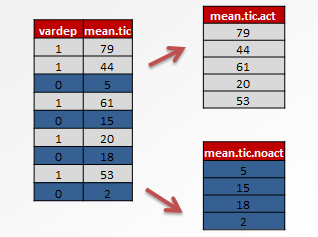

En **R** lo realizamos a través de un código similar al siguiente:

```r
df <- data.frame(vardep,data.num[, "mean.tic"])
mean.tic.act <- subset(df, subset=vardep==1)[,2]
mean.tic.noact <- subset(df, subset=vardep==0)[,2]
```

```r
# Estadistico KS
ks <- ks.test(mean.tic.act, mean.tic.noact)
ks
```

```
##
##  Two-sample Kolmogorov-Smirnov test
##
## data:  mean.tic.act and mean.tic.noact
## D = 0.9561, p-value < 2.2e-16
## alternative hypothesis: two-sided
```